# Basic Statistics

Christian Urcuqui

21 de febrero de 2019

Unidades de a revisar en este notebook:

- Distribución de probabilidad normal
- Distribución de probabilidad t-student
- Distribución de probabilidad Chi-cuadrado
- Intervalos de confianza
- Pruebas de hipótesis
- ANOVA de una vía
- Tamaño de una muestra

## Distribución de probabilidad normal

### Estadísticos descriptivos

Vamos a revisar las medidas de tendencia central, variabilidad y de distribución para *variables continuas*. Analizaremos estas medidas con el dataset de Motor Trend Road Tests (mtcars), nuestro enfoque se centrará sobre las variables que representan las millas por galón (mpg), los caballos de fuerza (hp), y peso (wt).

```r
vars <- c("mpg", "hp", "wt")
head(mtcars[vars])
```

```
##                    mpg  hp    wt
## Mazda RX4         21.0 110 2.620
## Mazda RX4 Wag     21.0 110 2.875
## Datsun 710        22.8  93 2.320
## Hornet 4 Drive    21.4 110 3.215
## Hornet Sportabout 18.7 175 3.440
## Valiant           18.1 105 3.460
```

Existen distintas funciones que nos permiten obtener un conjunto de estadísticos descriptivos, en primer lugar, podemos encontrar en la instalación base la función summary(), veamos el ejemplo

*Ejemplo 1*

```r
summary(mtcars[vars])
```

```
##       mpg              hp              wt
##  Min.   :10.40   Min.   : 52.0   Min.   :1.513
##  1st Qu.:15.43   1st Qu.: 96.5   1st Qu.:2.581
##  Median :19.20   Median :123.0   Median :3.325
##  Mean   :20.09   Mean   :146.7   Mean   :3.217
##  3rd Qu.:22.80   3rd Qu.:180.0   3rd Qu.:3.610
##  Max.   :33.90   Max.   :335.0   Max.   :5.424
```

Como podemos ver en el ejemplo, la función nos permite obtener el valor mínimo, el primer cuartil, la mediana, la media, el tercer cuartil y el valor máximo por cada variable cuantitativa y las frecuencias para los factores y los vectores lógicos.

Otra forma es utilizar la funciones apply() o sapply() que permite seleccionar los estadísticos descriptivos que nosotros quisiéramos utilizar.

*Ejemplo 2*

```r
# definimos una función con el nombre mystats
mystats <- function(x, na.omit=FALSE){
  if(na.omit)
    x <- x[!is.na(x)] # validamos los valores na con con el parámetro
  m <- mean(x)
  n <- length(x)
  s <- sd(x)
  skew <- sum((x-m)^3/s^3)/n  # sesgo
  kurt <- sum((x-m)^4/s^4)/n - 3 # curtosis
  ma <- max(x) # maximo
  mi <- min(x) #minimo
  return(c(n=n, mean=m, stdev=s, skew=skew, kurtosis=kurt, maximo = ma, minimo = mi))
}
sapply(mtcars[vars], mystats)
```

```
##                mpg          hp          wt
## n        32.000000  32.0000000 32.00000000
## mean     20.090625 146.6875000  3.21725000
## stdev     6.026948  68.5628685  0.97845744
## skew      0.610655   0.7260237  0.42314646
## kurtosis -0.372766  -0.1355511 -0.02271075
## maximo   33.900000 335.0000000  5.42400000
## minimo   10.400000  52.0000000  1.51300000
```

Para estos tenemos los siguientes estadísticos descriptivos + una desviación estándar de 6.0 + una distribución con sesgo hacia la derecha (+0.61) + algo más plana que una distribución normal (-0.37)

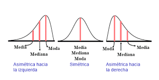